# CONNECT Program Matching

University of Texas at Austin, Spring 2022

Ethan Tenison (RGK Center for Philanthropy and Community Service)https://rgkcenter.org/  
December 05, 2021

Every semester the CONNECT Program pairs community organizations with graduate students with data and evaluation skills. As the program has expanded, the matching process has become more complicated, necessitating improved program efficiency. The following document outlines how survey data is taken from Qualtrics, cleaned and sorted, and then matched using the Gale-Shapley Algorithm. Some descriptive data visualizations were included as well to give program managers a snap shot of the semester cohort.

# Projects

### Project Descriptions

Each project is unique, and some are more complex than others. When you are evaluating who should be placed with what organizations, it’s important to keep in my the project goals and deliverables, even if they end up changing. The table below was pulled directly from the organization surveys, and it outlines the project goals, deliverables, and extra considerations.

```r
org <- read_csv("data/raw/CONNECT_organization_spring2022.csv") |>
  select(-c(1:17)) |>
  filter(!row_number() %in% c(2)) |>
  janitor::row_to_names(1) |>
  clean_names() |>
  rename_with(~ gsub('please_rate_how_relevant_the_following_technical_skills_are_to_your_project_', '', .x)) |>
  rename(nonprofit_experience = "how_much_experience_working_or_volunteering_with_nonprofits_should_your_candidate_have_working_or_volunteering_for_nonprofits",
             time_commitment = realistically_how_much_time_do_you_expect_your_student_to_commit_per_week_working_on_your_assigned_project,
    transportation = does_your_candidate_need_to_have_access_to_transportation,
    flexible_hours = will_your_project_permit_flexible_work_hours,
    remote = will_your_candidate_be_able_to_work_remotely) |>
  filter(which_connect_program_is_this_project_affiliated_with == "RGK Center") # Change this depending on school

#write.csv(org, "data/processed/utd_spring_2022.csv", row.names = FALSE)

proj_des <- org |>
  select(
    project_name,
    project_goal,
    project_deliverables,
    what_other_relevant_skills_would_be_helpful_for_your_candidate_to_have_i_e_other_languages_spoken_coding_analytical_software_professional_skills_etc_list_them_here
  ) |>
  rename(
    Project = project_name,
    Goal = project_goal,
    Deliverables = project_deliverables,
    "Other Considerations" = what_other_relevant_skills_would_be_helpful_for_your_candidate_to_have_i_e_other_languages_spoken_coding_analytical_software_professional_skills_etc_list_them_here
  ) |>
  arrange(Project) |>
  mutate(`Other Considerations` = replace_na(`Other Considerations`, ""),
         Deliverables = gsub('(\\s\\d)\\)', '<br><br>\\1\\.', Deliverables))


kbl(proj_des, escape = F) |>
  kable_minimal("hover", full_width = T) |>
  scroll_box(width = "100%", height = "600px")
```

Project

Goal

Deliverables

Other Considerations

Athletes For Hope - project 1

To improve Athletes For Hope’s ability to measure and track the impact of its programming on its two core client groups â€“ collegiate athletes and Paralympic/Olympic athletes.

1. Conduct research on best practices to define key outputs, short- and long-term outcomes, and metrics;  
   2. Update existing logic model(s) to include findings from deliverable #1; and  
   3. Develop/refine data collection tools (e.g. pre-/post-surveys, focus group interview protocols, etc.) aligned to the updated logic model

Athletes For Hope - project 2

To strengthen Athletes for Hope’s ability to measure and track its impact on its partners (e.g. children, hospital patients part of AFH Fit, Hospital Heroes and Miracle Moments programs).

1. Conduct research on best practices to define key outputs, short- and long-term outcomes, and metrics;  
   2. Develop a partner-specific logic model using findings from deliverable #1;  
   3. Develop data collection plan for tracking outputs and outcomes outlined in partner-specific logic model, including tools/methodology, data collection frequency, and cadence, etc.; and  
   4. Develop/refine data collection tools aligned to partner-specific logic model (if time allows)

Austin Asian Impact

To summarize and visualize the financial well-being of Asian-focused non-profits in Austin.

1. Design a survey that gathers information on the financial health of Asian-led and Asian-serving nonprofits in Austin and social impact numbers (e.g. volunteer hours, estimate of dollar number in impact and raised) of 30 â€“ 55% of the nonprofits AAI focuses on;  
   2. Administer survey (with support of AAI team) and collect supplemental, financial-health related data using IRS 990s (if applicable);  
   3. Analyze survey responses and 990 data (if applicable) and categorize the organizations surveyed through the impact they are making; and  
   4. Develop a summary and visualizations (including Kumu, Observable and Keep Fluent platform) outlining findings from analysis

Bastrop County Cares

To develop a dashboard for economic stability that can be expanded to include other Bastrop County indicators of interest.

1. Continue building out the dashboard developed during previous semester/phase (e.g. adding new features and data layers);  
   2. Conduct user testing of dashboard with key stakeholders (e.g. coalition partners, community members, etc.);  
   3. Analyze and summarize feedback from user testing; and  
   4. Incorporate findings from user testing into new version of the dashboard (as needed)

R and Tableau proficiency required

E4 Youth

To improve E4 Youth’s ability to measure and track the outcomes of its core programs.

1. Define the measurement strategies for E4 Youth’s core programs (as needed);  
   2. Develop new and/or modify current data collection tools so they are aligned to E4 Youth’s updated program logic models and measurement strategies; and  
   3. Set of recommendations/user manual outlining specific directions for administering data collection tools

Financial Health Pathways

To collect qualitative data for the financial health assessment being conducted for the Central Texas region.

1. Refine/improve the focus group interview protocols previously developed during Fall 2021 (as needed);  
   2. Coordinate and conduct focus groups with individual and service provider respondents from Qualtrics survey previously administered during Fall 2021. (Note â€“ some focus groups may need to be conducted in Spanish); and  
   3. Prep focus group notes and transcripts for analysis (e.g. translating focus groups conducted in Spanish)

Spanish fluency (both written and verbal) required

George Washington Carver Museum

To collect relevant data so that the Carver Museum can tell the stories of Austin’s Black founding families and quantify what the land previously owned by them is worth today.

1. Develop an interview protocol for oral histories to be conducted with descendants of Austin’s Black founding families;  
   2. Conduct oral histories with nine of Austin’s Black founding families;  
   3. Identify additional data points of interest and their data sources; and  
   4. Compile data points identified in deliverable #1

museum/archival studies background preferred; previous experience conducting oral histories and/or with qualitative research preferred

Good Apple

To understand the reach and impact of Good Apple’s Stay Home, Stay Healthy program during the past two years.

1. Compile Stay Home, Stay Healthy program data (client demographics + delivery information) into one dataset and prep/clean for analysis;  
   2. Run descriptive statistics and conduct exploratory analysis on dataset;  
   3. Develop summary/communication documents outlining findings from analysis (e.g. one-pagers, slide deck, infographics, etc.); and  
   4. Evaluate state of Good Apple’s other client data and provide recommendations for ways to combine and restructure for more efficient analyses

Leadership Austin - project 1

To improve Leadership Austin’s ability to determine if its new issues-based curriculum and approach is making a community impact.

1. Analysis of past cohort survey data for both Essential and Engage programs;  
   2. Research on promising practices for troubleshooting and measuring the impact of group think, specifically taking into account how it impacts inclusive leadership and anti-racism (as this relates to Essential programming) and measuring the impact of the Engage program;  
   3. Set of recommendations outlining solutions for troubleshooting the impact of group think on Leadership Austin’s programming, key outputs and outcomes associated with measuring the impact of Essential and Engage, and suggestions for refining current or developing new data collection tools aligned to aforementioned recommendations and deliverables

willingness to practice a racial equity lens and general knowledge of civic leadership preferred

Leadership Austin - project 2

To assist the program director with the design of community, issues-based curriculum and themes for Leadership Austin’s key programs â€“ Essential and Engage.

1. Research issues (criminal justice, healthcare, economy, education, institutional racism, etc.) to be included in Essential curriculum;  
   2. Research current events and themes to be incorporated into Engage panel-series;  
   3. Assist with identifying appropriate speakers related to deliverables #1 and #2 for Essential and Engage programming;  
   4. Develop other Essential curriculum-support resources (e.g. shared vocabulary and language for discussing various issue topics); and  
   5. Assist with developing social media and blog content for Engage panel-series

willingness to practice a racial equity lens, an interest or desire to learn and design issues-based curriculum for adult leaders, and general knowledge of civic leadership preferred

Leadership Equality Academy

To better understand the landscape of domestic initiatives and programming focused on developing women from marginalized communities into roles of thought leaders (e.g. board members) and C-Level executives and encouraging them to return to their communities to give back.

1. Conduct a landscape analysis to identify similar initiatives* and programming currently underway across the U.S., specifically focusing on: promising practices and lessons learned, how other entities are defining and measuring success, and who other entities are partnering with;  
   2. Conduct additional research on: current disparities in leadership diversity and the barriers and disruptions that perpetuate this, benefits of having diverse leaders;  
   3. “Pitch book” summarizing findings from deliverables #1 and #2 for engaging funders, sponsors, and/or potential partners; and  
   4. Set of recommendations outlining ways to bolster Leadership Equality Academy’s current strategy toward carrying out its mission (e.g. list of potential, strategic partnerships to explore, suggestions for tweaks or additions to program model, potential grants that might be a good match for LEA to apply for)

CONNECT Fellow who identifies as a woman preferred

Rebuilding Together Austin

To determine the amount of energy Rebuilding Together Austin is saving its clients through home repair.

1. Collaborate with Austin Energy to gather homeowner energy use data for approximately 100 Rebuilding Together Austin clients;  
   2. Analyze data for energy savings (e.g. water consumption, utilities, etc.) achieved after home repairs;  
   3. Develop visualizations that depict/summarize findings from analysis; and  
   4. Present findings to coalition members

Texas Higher Education Coordinating Board

To examine recently-submitted recommended course sequence data from Texas universities and community colleges to identify patterns on dimensions such as programs/majors and institution types and to inform reporting back to Texas universities and community colleges to support course sequencing, academic program planning, and academic advising.

1. Prep/clean data for analysis;  
   2. Run descriptive statistics and conduct exploratory analysis on dataset, ideally comparing current course-taking patterns with recommended course sequences;  
   3. Develop data visualizations and other communication tools (e.g report, slide deck, 1-pager, etc.) to summarize findings from analysis;  
   4. Develop mock ups for reports back to institutions to inform course sequencing, academic program planning, and/or academic advising

Texas Higher Education Coordinating Board - project 2

To support the integration of high-value national data sets into the Texas data ecosystem with higher education and workforce data at Texas Higher Education Coordinating Board to produce insightful analysis for institutional leaders and stakeholders. This data and analysis will also contribute to tracking measures toward Texas 60x30TX strategic plan for higher education.

1. Pull, prep and integrate national data sets into THECB data;  
   2. Run preliminary analysis on these data sets;  
   3. Develop and document an improved process to pull and maintain data for analysis purposes; and  
   4. Explore and provide recommendations for other relevant national data sets for integration into THECB data offerings

Experience with data set development, data analysis, and data visualization required; fluency with programming languages such as SAS, R, or Python

TransFORWARD

To describe the transgender and gender diverse adult population in Texas to improve health outcomes.

1. Work with TransFORWARD team and its collaborators to identify the datapoints relevant to describing the transgender and gender diverse adult population in Texas;  
   2. Compile relevant data sources in a central location; clean and restructure as needed;  
   3. Work with TransFORWARD team and its collaborators to create a dashboard concept;  
   4. Develop dashboard and other data visualizations useful for stakeholder, health policy and education communication; and  
   5. List of datapoints (that are currently unavailable) to be included as questions in any future data collection efforts

### Organization Data

Ordinal questions for both student and organization surveys were converted to a numeric scale. For example, for the question “How much working or volunteering with nonprofits should your candidate have?” the responses were converted from 1 to 5, with “No experience required” being 1 and “2 or more years” being 5. This is done because the algorithm can only compare numeric values.

```r
org_mapping <- org |>
  select(organization,
        organization_address,
        organization_website
        )

org2 <- org |>
  select(
    organization,
    project_name,
    project_goal,
    project_deliverables,
    transportation,
    flexible_hours,
    remote,
    time_commitment,
    nonprofit_experience,
    23:47
  ) |>
  mutate(
    nonprofit_experience = case_when(
      nonprofit_experience == "No experience required" ~ "1",
      nonprofit_experience == "Less than 6 months" ~ "2",
      nonprofit_experience == "6 - 12 months" ~ "3",
      nonprofit_experience == "1 - 2 years" ~ "4",
      nonprofit_experience == "2 or more years" ~ "5",
      TRUE ~ nonprofit_experience
    ),
    time_commitment = case_when(
      time_commitment == "Less than 5 hours per week" ~ "1",
      time_commitment == "5 - 10 hours per week" ~ "2",
      time_commitment == "8 - 12 hours per week" ~ "3",
      time_commitment == "10 - 15 hours per week" ~ "4",
      time_commitment == "15 - 20 hours per week" ~ "5"
    )
  ) |>
  arrange(project_name) |>
  mutate(across(9:34,~gsub("1 - Not relevant", "1", .)),
         across(9:34,~gsub("5 - Extremely relevant", "5", .)),
         across(8:34, as.numeric))


#For Table
org_table <- org2 |>
  select(-c(organization, project_deliverables, project_goal))

names(org_table) <- gsub(pattern = "_",
                         replacement = " ",
                         x = names(org_table))

names(org_table) <- str_to_title(names(org_table))

cell_color <- function(x) {
  x = cell_spec(x,
                color = spec_color(x, end = .7),
                bold = T,)
}

org_table <- org_table |>
  select(-Transportation, -`Flexible Hours`,-Remote, everything()) |>
  mutate(across(2:28, cell_color))

kbl(org_table, escape = F) |>
  kable_material(c("hover", "striped", "condensed"), full_width = F) |>
  scroll_box(width = "100%", height = "400px")
```

| Project Name | Time Commitment | Nonprofit Experience | Tableau | Literature Review | Conducting Interviews | Program Evaluation | Logic Modeling | Html | Arc Gis | Outcomes Definition | Microsoft Office Suite | Google Data Studio | R Shiny | Statistical Analysis | Consulting | Baseline Data Identification | Machine Learning | Project Management | Survey Design | Sql | R | Javascript | Data Mining | Java | Python | Css | Power Bi | Transportation | Flexible Hours | … |
| --- | --- | --- | --- | --- | --- | --- | --- | --- | --- | --- | --- | --- | --- | --- | --- | --- | --- | --- | --- | --- | --- | --- | --- | --- | --- | --- | --- | --- | --- | --- |
| Athletes For Hope - project 1 | 2 | 3 | 1 | 5 | 5 | 5 | 5 | 1 | 1 | 5 | 1 | 1 | 1 | 1 | 1 | 1 | 1 | 1 | 5 | 1 | 1 | 1 | 1 | 1 | 1 | 1 | 1 | No | Yes | … |
| Athletes For Hope - project 2 | 2 | 3 | 1 | 5 | 3 | 5 | 5 | 1 | 1 | 5 | 1 | 1 | 1 | 1 | 1 | 1 | 1 | 1 | 2 | 1 | 1 | 1 | 1 | 1 | 1 | 1 | 1 | No | Yes | … |
| Austin Asian Impact | 2 | 3 | 5 | 3 | 1 | 1 | 1 | 1 | 1 | 1 | 1 | 1 | 1 | 5 | 5 | 1 | 1 | 3 | 5 | 1 | 3 | 1 | 1 | 1 | 1 | 1 | 1 | No | Yes | … |
| Bastrop County Cares | 3 | 1 | 5 | 1 | 2 | 1 | 1 | 1 | 1 | 1 | 1 | 1 | 1 | 1 | 2 | 1 | 1 | 1 | 2 | 1 | 5 | 1 | 1 | 1 | 1 | 1 | 1 | No | Yes | … |
| E4 Youth | 2 | 2 | 1 | 5 | 5 | 5 | 3 | 1 | 1 | 3 | 1 | 1 | 1 | 1 | 1 | 1 | 1 | 1 | 5 | 1 | 1 | 1 | 1 | 1 | 1 | 1 | 1 | No | Yes | … |
| Financial Health Pathways | 2 | 3 | 1 | 1 | 5 | 1 | 1 | 1 | 1 | 1 | 1 | 1 | 1 | 1 | 1 | 1 | 1 | 5 | 5 | 1 | 1 | 1 | 1 | 1 | 1 | 1 | 1 | Yes | Yes | … |
| George Washington Carver Museum | 3 | 1 | 1 | 5 | 5 | 1 | 1 | 1 | 1 | 1 | 1 | 1 | 1 | 1 | 1 | 1 | 1 | 3 | 3 | 1 | 1 | 1 | 1 | 1 | 1 | 1 | 1 | Yes | Yes | … |
| Good Apple | 2 | 1 | 1 | 1 | 1 | 1 | 1 | 1 | 1 | 1 | 3 | 1 | 1 | 2 | 1 | 1 | 1 | 1 | 1 | 1 | 3 | 1 | 3 | 1 | 3 | 1 | 1 | No | Yes | … |
| Leadership Austin - project 1 | 2 | 4 | 1 | 5 | 1 | 3 | 3 | 1 | 1 | 5 | 1 | 1 | 1 | 5 | 3 | 3 | 1 | 1 | 1 | 1 | 1 | 1 | 1 | 1 | 1 | 1 | 1 | Yes | Yes | … |
| Leadership Austin - project 2 | 3 | 1 | 1 | 5 | 3 | 1 | 1 | 1 | 1 | 1 | 1 | 1 | 1 | 1 | 1 | 1 | 1 | 1 | 1 | 1 | 1 | 1 | 1 | 1 | 1 | 1 | 1 | Yes | Yes | … |
| Leadership Equality Academy | 2 | 1 | 1 | 5 | 3 | 1 | 1 | 1 | 1 | 1 | 1 | 1 | 1 | 1 | 3 | 1 | 1 | 3 | 1 | 1 | 1 | 1 | 1 | 1 | 1 | 1 | 1 | No | Yes | … |
| Rebuilding Together Austin | 2 | 1 | 5 | 1 | 1 | 1 | 1 | 1 | 1 | 1 | 1 | 5 | 1 | 5 | 1 | 1 | 1 | 1 | 1 | 1 | 5 | 1 | 3 | 1 | 5 | 1 | 1 | No | Yes | … |
| Texas Higher Education Coordinating Board | 3 | 1 | 5 | 1 | 1 | 1 | 1 | 1 | 1 | 1 | 1 | 1 | 1 | 5 | 1 | 1 | 1 | 1 | 1 | 1 | 5 | 1 | 3 | 1 | 3 | 1 | 1 | No | Yes | … |
| Texas Higher Education Coordinating Board - project 2 | 3 | 1 | 5 | 1 | 1 | 1 | 1 | 1 | 1 | 1 | 1 | 1 | 1 | 5 | 1 | 1 | 1 | 1 | 1 | 1 | 5 | 1 | 3 | 1 | 5 | 1 | 1 | No | Yes | … |
| TransFORWARD | 3 | 1 | 5 | 1 | 1 | 1 | 1 | 1 | 1 | 1 | 1 | 1 | 1 | 1 | 2 | 1 | 1 | 1 | 1 | 1 | 3 | 1 | 1 | 1 | 1 | 1 | 1 | No | Yes | … |

### Project Buckets

There were 15 projects, but some of them involve multiple buckets. Of note, this semester there were zero web design projects. Projects that were continuations from previous semester, or were pre-matched were also not included.

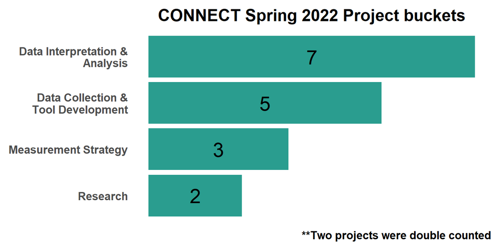

```r
buckets <- org |>
  select(
    organization,
    identify_the_categories_your_project_falls_under_check_all_that_apply
  ) |>
  rename(bucket = identify_the_categories_your_project_falls_under_check_all_that_apply) |>
  group_by(bucket) |>
  count() |>
  mutate(
    n = as.numeric(n),
    ### Just for RGK THIS ROUND because of duplicates
    n = case_when(
      bucket == "Data Collection & Tool Development" ~ n + 2,
      bucket == "Data Interpretation & Analysis" ~ n + 2,
      TRUE ~ n
    ),
    bucket = case_when(
      bucket == "Data Collection & Tool Development" ~ "Data Collection &\n Tool Development",
      bucket == "Data Interpretation & Analysis" ~ "Data Interpretation &\n Analysis",
      bucket == "Business Intelligence & Advanced Analytics" ~ "Business Intelligence &\n Advanced Analytics",
      TRUE ~ bucket
    )
  ) |>
  arrange(n) |>
  filter(bucket != "Data Collection & Tool Development,Data Interpretation & Analysis")


theme_set(theme_classic())

g <- ggplot(buckets, aes(x = reorder(bucket, n), y = n)) +
  geom_bar(stat = "identity", fill = "#2A9D8F") +
    geom_text(aes(label = n, y = n),
    position = position_stack(vjust = 0.5),
    size = 8) +
  coord_flip()+
   theme(
    panel.grid.major = element_blank(),
    panel.grid.minor = element_blank(),
    axis.line = element_blank(),
     text = element_text(
                         size = 16,
                         face = "bold"),
     axis.title.x = element_blank(),
     axis.title.y = element_blank(),
     axis.ticks = element_blank(),
      axis.text.x=element_blank(),
     plot.title = element_text(hjust = 0.5),
     plot.margin = margin(10, 10, 10, 10),
     legend.title = element_blank(),
     legend.position = "none",

   ) +
  labs(title = "CONNECT Spring 2022 Project buckets",
       y = "Number",
       fill = "Buckets",
       caption = "**Two projects were double counted")


g
```

### Organization Location

```r
library(ggmap)
library(leaflet)
register_google(Sys.getenv("google_geocode_key"))

geo_o <- org |>
  filter(which_connect_program_is_this_project_affiliated_with == "RGK Center") |>
  select(organization, organization_address) |>
  mutate(organization_address = case_when(
    organization_address == "N/A" ~ "",
    TRUE ~ organization_address
  )) |>
  distinct(organization_address, .keep_all = TRUE) |>
  mutate_geocode(organization_address)

# create leaflet map
org_map <- leaflet(geo_o) %>%
  addTiles() %>%
  addMarkers(lng = ~ lon,
             lat = ~ lat,
             popup = ~ organization)

org_map
```

[interactive chart not shown]

### Project Wordcloud

Project CONNECT continues to offer a diverse set of projects to students. The word cloud below shows the most common words located in the project deliverable section. What’s clear about this cohort is that data is king, and we a wide variety of projects and deliverables.

```r
library(wordcloud)
library(RColorBrewer)
library(tm) # to create corpus
library(wordcloud2)
library(htmlwidgets)


# Create a vector containing only the text
text <- org$project_deliverables

# Create a corpus
docs <- Corpus(VectorSource(text))

# standardize corpus
docs <- docs %>%
  tm_map(removeNumbers) %>%
  tm_map(removePunctuation) %>%
  tm_map(stripWhitespace)
docs <- tm_map(docs, content_transformer(tolower))
docs <- tm_map(docs, removeWords, stopwords("english"))

# create a document matrix
dtm <- TermDocumentMatrix(docs)
matrix <- as.matrix(dtm)
words <- sort(rowSums(matrix), decreasing = TRUE)
df <- data.frame(word = names(words), freq = words)
df$word <- as.character(df$word)
target <- c("also", "project", "really", "helpful", "able", "helped", "felt", "wasnt", "etc", "asks", "move", "gave")
"%ni%" <- Negate("%in%")
df <- filter(df, word %ni% target)
df$word <- as.factor(df$word)

set.seed(27)


w1 <-
  wordcloud2(data = df,
             shuffle = FALSE)


w1
```

[interactive chart not shown]

# Students

### Student Data

Because CONNECT uses a formalized survey structure, the data cleaning process for student and organization survey data is virtually the same. The table below includes student skills and experience ratings as well as answers from logistics questions.

```r
stu <- read_csv("data/raw/CONNECT_rgk_students_spring2022.csv") |>
  select(-c(1:17)) |>
  filter(!row_number() %in% c(2)) |>
  janitor::row_to_names(1) |>
  clean_names() |>
  rename(pronouns = preferred_pronouns_selected_choice,
         phone = phone_number_please_do_not_include_hyphens_or_parentheses,
         relevant_skills = do_you_have_other_relevant_skills_that_may_be_helpful_for_us_to_know_about_i_e_other_languages_spoken_list_them_here_note_separate_each_skill_with_a_comma,
         target_population = every_semester_the_connect_program_works_with_organizations_that_serve_many_different_target_populations_are_there_any_specific_populations_that_youre_interested_in_working_with,
         nonprofit_experience = over_the_past_5_years_approximately_how_much_experience_have_you_had_working_or_directly_volunteering_with_nonprofit_organizations,
         schools = which_ut_schools_colleges_are_you_affiliated_with_check_all_that_apply_selected_choice,
         schools_other = which_ut_schools_colleges_are_you_affiliated_with_check_all_that_apply_other_text,
         international = to_comply_with_university_rules_and_regulations_please_indicate_if_you_are_an_international_student_please_note_that_this_does_not_prohibit_participation_in_this_program) |>
  rename_with(~ gsub('please_rate_your_experience_in_the_following_technical_skills_note_1_not_experienced_and_5_extremely_experienced_', '', .x))


stu4 <- stu |>
  select(
    first_name,
    last_name,
    is_there_any_additional_information_regarding_your_availability_that_we_should_know_about,
    do_you_have_access_to_transportation,
    do_you_need_flexible_work_hours,
    do_you_need_the_ability_to_work_remotely,
    realistically_how_much_time_can_you_commit_per_week_to_working_on_a_project,
    29:56
  ) |>
    rename(
      time_commitment = realistically_how_much_time_can_you_commit_per_week_to_working_on_a_project,
      transportation = do_you_have_access_to_transportation,
      flexible_hours = do_you_need_flexible_work_hours,
      remote = do_you_need_the_ability_to_work_remotely) |>
  mutate(nonprofit_experience = case_when(
    nonprofit_experience == "No experience (yet!)" ~ "1",
    nonprofit_experience == "Less than 6 months" ~ "2",
    nonprofit_experience == "6 - 12 months" ~ "3",
    nonprofit_experience == "1 - 2 years" ~ "4",
    nonprofit_experience == "2 or more years" ~ "5",
  ),
  time_commitment = case_when(
    time_commitment == "Less than 5 hours per week" ~ "1",
    time_commitment == "5 - 10 hours per week" ~ "2",
    time_commitment == "8 - 12 hours per week" ~ "3",
    time_commitment == "10 - 15 hours per week" ~ "4",
    time_commitment == "15 - 20 hours per week" ~ "5"

  )) |>
  mutate(across(7:33, as.numeric),
         name = paste0(first_name," ", last_name))

stumas <- stu4

stu4 <- stu4 |>
  select(name, time_commitment, 4:35) |>
  arrange(str_extract(name,'\\s.*$'))


#For table
stu_table <- stu4 |>
  select(-c(relevant_skills, target_population))

names(stu_table) <- gsub(pattern = "_",
                  replacement = " ",
                  x = names(stu_table))

names(stu_table) <- str_to_title(names(stu_table))


cell_color <- function(x) {
  x = cell_spec(x,
                color = spec_color(x, end = .7),
                bold = T,
                )
}

stu_table <- stu_table |>
  select(-Transportation,-`Flexible Hours`, -Remote, everything()) |>
  mutate(across(2:28, cell_color))


kbl(stu_table, escape = F) |>
  kable_material(c("hover", "striped", "condensed"), full_width = F) |>
  scroll_box(width = "100%", height = "400px")
```

| Name | Time Commitment | Nonprofit Experience | Literature Review | Program Evaluation | Consulting | Project Management | Baseline Data Identification | Logic Modeling | Outcomes Definition | Survey Design | Conducting Interviews | Data Mining | Statistical Analysis | Sql | Machine Learning | Html | Css | Java | Python | Tableau | Microsoft Office Suite | R | R Shiny | Arc Gis | Power Bi | Google Data Studio | Javascript | Transportation | Flexible Hours | … |
| --- | --- | --- | --- | --- | --- | --- | --- | --- | --- | --- | --- | --- | --- | --- | --- | --- | --- | --- | --- | --- | --- | --- | --- | --- | --- | --- | --- | --- | --- | --- |
| Deepshikha Arora | 2 | 2 | 3 | 1 | 1 | 1 | 1 | 4 | 1 | 1 | 1 | 4 | 4 | 1 | 1 | 1 | 1 | 1 | 1 | 1 | 3 | 3 | 1 | 1 | 1 | 1 | 1 | Yes | Yes | … |
| Debasmita Bhakta | 2 | 2 | 4 | 3 | 5 | 4 | 3 | 4 | 4 | 3 | 3 | 1 | 4 | 1 | 1 | 1 | 1 | 1 | 1 | 1 | 4 | 4 | 1 | 1 | 1 | 1 | 1 | No | Yes | … |
| Emily Cantwell | 2 | 5 | 4 | 4 | 2 | 4 | 2 | 2 | 4 | 3 | 3 | 2 | 4 | 1 | 2 | 2 | 1 | 1 | 3 | 1 | 5 | 4 | 1 | 2 | 1 | 2 | 1 | Yes | Yes | … |
| Da’Shon Carr | 3 | 5 | 4 | 5 | 5 | 5 | 5 | 4 | 5 | 5 | 5 | 4 | 3 | 1 | 2 | 2 | 1 | 1 | 1 | 3 | 5 | 4 | 3 | 1 | 1 | 3 | 1 | Yes | Yes | … |
| Francisco Castellanos-Sosa | 4 | 1 | 5 | 5 | 5 | 4 | 5 | 5 | 5 | 4 | 3 | 5 | 5 | 1 | 5 | 1 | 1 | 1 | 2 | 2 | 2 | 4 | 4 | 2 | 1 | 1 | 1 | Yes | No | … |
| Vanessa Chebli | 2 | 5 | 3 | 3 | 3 | 3 | 2 | 1 | 1 | 3 | 2 | 1 | 4 | 1 | 1 | 2 | 1 | 1 | 1 | 1 | 5 | 2 | 1 | 1 | 1 | 1 | 1 | Yes | Yes | … |
| Grace Chiu | 2 | 2 | 1 | 1 | 1 | 1 | 2 | 1 | 1 | 2 | 2 | 4 | 4 | 4 | 4 | 4 | 4 | 4 | 5 | 2 | 5 | 4 | 1 | 2 | 1 | 2 | 4 | No | Yes | … |
| Taylor Cox | 2 | 1 | 5 | 1 | 1 | 2 | 1 | 1 | 1 | 1 | 2 | 1 | 2 | 1 | 1 | 1 | 1 | 1 | 1 | 1 | 4 | 2 | 1 | 1 | 1 | 1 | 1 | Yes | Yes | … |
| Melissa Deuber | 5 | 1 | 5 | 1 | 2 | 2 | 1 | 1 | 1 | 3 | 3 | 1 | 2 | 4 | 1 | 3 | 1 | 1 | 1 | 1 | 5 | 1 | 1 | 3 | 1 | 1 | 1 | Yes | Yes | … |
| Ram Disabar Jr. | 2 | 2 | 4 | 4 | 5 | 4 | 3 | 3 | 4 | 4 | 5 | 4 | 4 | 1 | 3 | 1 | 1 | 1 | 3 | 1 | 5 | 1 | 1 | 3 | 1 | 2 | 1 | Yes | Yes | … |
| Angie Fong | 4 | 4 | 2 | 4 | 5 | 4 | 4 | 3 | 3 | 5 | 5 | 4 | 4 | 4 | 4 | 4 | 4 | 4 | 4 | 3 | 5 | 1 | 1 | 1 | 3 | 3 | 4 | Yes | No | … |
| Shelby Frye | 2 | 3 | 5 | 3 | 4 | 4 | 1 | 1 | 2 | 4 | 2 | 1 | 1 | 1 | 1 | 1 | 1 | 1 | 1 | 1 | 4 | 1 | 1 | 1 | 1 | 1 | 1 | Yes | Yes | … |
| Jaren Gaither | 2 | 4 | 5 | 2 | 5 | 5 | 3 | 4 | 3 | 4 | 4 | 1 | 4 | 1 | 1 | 1 | 1 | 1 | 2 | 3 | 5 | 3 | 1 | 1 | 1 | 1 | 1 | Yes | Yes | … |
| Elena Gonzales Melinger | 3 | 5 | 4 | 4 | 4 | 5 | 5 | 2 | 4 | 5 | 5 | 1 | 3 | 2 | 2 | 1 | 1 | 1 | 1 | 3 | 5 | 1 | 1 | 1 | 1 | 1 | 1 | Yes | Yes | … |
| Tara Greig | 2 | 1 | 4 | 3 | 3 | 3 | 4 | 5 | 3 | 4 | 4 | 5 | 5 | 4 | 4 | 4 | 1 | 2 | 4 | 2 | 5 | 5 | 2 | 1 | 3 | 1 | 1 | Yes | Yes | … |
| Abigail Grider-Reiff | 3 | 5 | 5 | 2 | 2 | 3 | 5 | 3 | 4 | 4 | 5 | 5 | 5 | 1 | 3 | 1 | 1 | 1 | 1 | 1 | 5 | 5 | 1 | 1 | 1 | 2 | 2 | Yes | No | … |
| Brittany Head | 2 | 5 | 5 | 4 | 3 | 4 | 4 | 4 | 4 | 4 | 3 | 4 | 4 | 2 | 2 | 2 | 2 | 1 | 1 | 1 | 5 | 4 | 1 | 1 | 1 | 3 | 1 | No | No | … |
| Emily Hebel | 2 | 2 | 3 | 1 | 3 | 2 | 3 | 1 | 1 | 3 | 3 | 3 | 5 | 1 | 1 | 1 | 1 | 1 | 3 | 1 | 5 | 1 | 1 | 1 | 1 | 3 | 1 | Yes | Yes | … |
| Daisy Hernandez | 2 | 2 | 4 | 3 | 3 | 4 | 3 | 3 | 3 | 3 | 3 | 1 | 4 | 1 | 3 | 5 | 2 | 3 | 3 | 2 | 5 | 1 | 1 | 1 | 1 | 3 | 2 | Yes | Yes | … |
| Helen Ho | 2 | 2 | 2 | 3 | 2 | 3 | 2 | 1 | 2 | 3 | 3 | 2 | 4 | 1 | 2 | 2 | 1 | 1 | 3 | 1 | 5 | 2 | 1 | 1 | 2 | 3 | 1 | Yes | Yes | … |
| Ming-Hung Hung | 5 | 2 | 4 | 4 | 5 | 4 | 4 | 5 | 5 | 3 | 3 | 5 | 4 | 4 | 5 | 4 | 2 | 1 | 5 | 4 | 4 | 4 | 2 | 1 | 1 | 1 | 4 | Yes | Yes | … |
| Geethu Jacob | 3 | 1 | 5 | 2 | 3 | 4 | 1 | 1 | 2 | 1 | 3 | 4 | 5 | 3 | 4 | 2 | 1 | 1 | 5 | 3 | 4 | 3 | 1 | 1 | 1 | 1 | 1 | Yes | Yes | … |
| Pei-Syuan Jhang | 2 | 1 | 5 | 4 | 3 | 1 | 5 | 1 | 3 | 5 | 5 | 3 | 5 | 1 | 1 | 1 | 1 | 1 | 1 | 5 | 1 | 1 | 1 | 1 | 1 | 1 | 1 | Yes | Yes | … |
| Rui Jie Peng | 4 | 4 | 5 | 4 | 4 | 5 | 3 | 5 | 2 | 5 | 5 | 1 | 4 | 2 | 1 | 2 | 1 | 1 | 3 | 3 | 5 | 2 | 1 | 4 | 2 | 3 | 1 | Yes | Yes | … |
| Danya Kachkou | 2 | 5 | 5 | 4 | 4 | 5 | 5 | 2 | 2 | 4 | 5 | 1 | 3 | 1 | 1 | 1 | 1 | 1 | 1 | 1 | 5 | 1 | 1 | 1 | 1 | 3 | 1 | Yes | Yes | … |
| Isabel Keddy-Hector | 2 | 5 | 5 | 5 | 3 | 4 | 4 | 2 | 4 | 5 | 5 | 3 | 3 | 1 | 1 | 1 | 1 | 1 | 1 | 1 | 5 | 4 | 1 | 2 | 1 | 1 | 1 | Yes | Yes | … |
| Raeesa Khan | 3 | 3 | 3 | 2 | 5 | 4 | 2 | 1 | 4 | 3 | 2 | 1 | 2 | 1 | 1 | 2 | 2 | 1 | 1 | 1 | 5 | 2 | 1 | 3 | 1 | 1 | 1 | Yes | Yes | … |
| Michael Kiel | 3 | 5 | 4 | 4 | 3 | 5 | 3 | 2 | 3 | 3 | 4 | 2 | 4 | 1 | 1 | 2 | 1 | 1 | 3 | 4 | 5 | 1 | 1 | 5 | 3 | 2 | 1 | Yes | No | … |
| Jamie Kim | 3 | 2 | 5 | 1 | 3 | 1 | 2 | 3 | 2 | 3 | 1 | 2 | 4 | 2 | 1 | 1 | 1 | 1 | 2 | 1 | 5 | 4 | 1 | 4 | 1 | 1 | 1 | Yes | Yes | … |
| Matthew Kojm | 3 | 4 | 3 | 4 | 5 | 5 | 5 | 3 | 3 | 4 | 4 | 5 | 5 | 4 | 1 | 1 | 1 | 1 | 3 | 5 | 5 | 3 | 2 | 3 | 2 | 2 | 1 | Yes | No | … |
| Madison Laboy | 3 | 1 | 4 | 3 | 3 | 5 | 2 | 1 | 3 | 3 | 4 | 1 | 3 | 1 | 1 | 1 | 1 | 1 | 1 | 1 | 5 | 1 | 1 | 1 | 1 | 4 | 1 | Yes | Yes | … |
| Kim McErlean | 2 | 3 | 5 | 3 | 4 | 5 | 5 | 3 | 4 | 5 | 5 | 2 | 5 | 1 | 1 | 1 | 1 | 1 | 1 | 3 | 5 | 3 | 1 | 1 | 1 | 1 | 1 | Yes | Yes | … |
| Kliment Minchev | 3 | 3 | 4 | 2 | 3 | 2 | 3 | 3 | 3 | 4 | 4 | 5 | 5 | 4 | 5 | 4 | 4 | 3 | 5 | 2 | 3 | 3 | 1 | 1 | 2 | 2 | 3 | Yes | No | … |
| Isabel Morford-Cheibub | 2 | 5 | 4 | 3 | 3 | 4 | 2 | 1 | 2 | 2 | 2 | 1 | 3 | 2 | 1 | 1 | 1 | 1 | 1 | 1 | 5 | 2 | 1 | 3 | 1 | 1 | 1 | Yes | No | … |
| Christopher Ndubuizu | 3 | 5 | 5 | 5 | 5 | 5 | 5 | 5 | 5 | 5 | 5 | 3 | 4 | 1 | 1 | 1 | 2 | 2 | 2 | 2 | 5 | 2 | 2 | 2 | 2 | 2 | 2 | No | Yes | … |
| Niina Nomura | 2 | 4 | 5 | 4 | 4 | 4 | 4 | 4 | 4 | 4 | 3 | 1 | 2 | 1 | 1 | 1 | 1 | 1 | 1 | 4 | 5 | 2 | 1 | 1 | 1 | 1 | 1 | Yes | Yes | … |
| Marissa Nunez | 4 | 5 | 1 | 2 | 3 | 4 | 3 | 1 | 1 | 1 | 4 | 1 | 1 | 1 | 1 | 1 | 1 | 1 | 1 | 1 | 5 | 1 | 1 | 1 | 1 | 1 | 1 | Yes | Yes | … |
| Abundance Ogodogu Chima | 2 | 5 | 3 | 3 | 2 | 2 | 2 | 2 | 2 | 2 | 4 | 3 | 1 | 1 | 1 | 1 | 1 | 1 | 1 | 1 | 3 | 1 | 1 | 1 | 1 | 1 | 1 | No | Yes | … |
| Madie Olson Spartz | 2 | 5 | 3 | 3 | 2 | 4 | 4 | 1 | 4 | 3 | 3 | 1 | 3 | 1 | 1 | 1 | 1 | 1 | 1 | 1 | 5 | 1 | 1 | 1 | 1 | 1 | 1 | Yes | Yes | … |
| Sabrina Page | 2 | 4 | 3 | 1 | 1 | 4 | 1 | 1 | 1 | 2 | 3 | 1 | 2 | 1 | 1 | 1 | 1 | 1 | 1 | 1 | 4 | 1 | 1 | 1 | 3 | 1 | 1 | Yes | No | … |
| Afnaan Qayyum | 2 | 5 | 4 | 4 | 4 | 4 | 4 | 1 | 2 | 4 | 4 | 2 | 3 | 1 | 1 | 1 | 1 | 1 | 2 | 1 | 4 | 1 | 1 | 1 | 1 | 1 | 1 | No | Yes | … |
| Sravan Reddy Chilumula | 5 | 1 | 5 | 5 | 4 | 5 | 5 | 4 | 4 | 3 | 4 | 3 | 4 | 5 | 3 | 5 | 5 | 5 | 5 | 3 | 4 | 4 | 2 | 2 | 3 | 3 | 5 | Yes | Yes | … |
| Het Ripple Patel | 3 | 4 | 4 | 4 | 5 | 5 | 4 | 4 | 4 | 3 | 4 | 4 | 5 | 4 | 4 | 3 | 1 | 2 | 4 | 4 | 5 | 3 | 2 | 1 | 3 | 3 | 1 | No | Yes | … |
| Srujan Rode | 4 | 2 | 1 | 4 | 4 | 4 | 4 | 2 | 3 | 3 | 3 | 3 | 2 | 4 | 1 | 1 | 1 | 1 | 1 | 3 | 4 | 2 | 1 | 1 | 4 | 1 | 1 | Yes | Yes | … |
| Patricia Romero | 1 | 5 | 2 | 4 | 2 | 5 | 1 | 1 | 1 | 1 | 5 | 1 | 1 | 1 | 1 | 1 | 1 | 1 | 1 | 1 | 5 | 1 | 1 | 1 | 1 | 5 | 1 | Yes | Yes | … |
| Lauren Rosa | 1 | 5 | 5 | 4 | 3 | 5 | 3 | 1 | 1 | 4 | 4 | 1 | 1 | 1 | 1 | 1 | 1 | 1 | 1 | 1 | 5 | 2 | 1 | 1 | 1 | 1 | 1 | Yes | Yes | … |
| Ishita Roy | 3 | 1 | 3 | 1 | 3 | 2 | 4 | 1 | 1 | 1 | 2 | 3 | 3 | 5 | 4 | 2 | 2 | 1 | 5 | 5 | 4 | 2 | 1 | 1 | 4 | 3 | 1 | Yes | Yes | … |
| Mikhaela Sample | 2 | 3 | 2 | 1 | 1 | 5 | 2 | 4 | 2 | 1 | 2 | 1 | 4 | 1 | 1 | 1 | 1 | 1 | 1 | 1 | 5 | 3 | 1 | 2 | 1 | 1 | 1 | Yes | Yes | … |
| Holly Sarkissian | 3 | 5 | 5 | 5 | 5 | 5 | 4 | 4 | 5 | 4 | 4 | 4 | 3 | 3 | 2 | 1 | 1 | 1 | 1 | 3 | 5 | 3 | 1 | 4 | 3 | 2 | 1 | Yes | No | … |
| Neil Schwartz | 2 | 2 | 5 | 4 | 2 | 3 | 3 | 3 | 3 | 2 | 5 | 1 | 4 | 1 | 1 | 1 | 1 | 1 | 1 | 1 | 5 | 4 | 1 | 2 | 1 | 1 | 1 | Yes | No | … |
| Rania Sohail | 2 | 5 | 5 | 2 | 4 | 2 | 4 | 4 | 4 | 4 | 5 | 3 | 3 | 1 | 1 | 1 | 1 | 1 | 1 | 1 | 5 | 4 | 1 | 1 | 1 | 1 | 1 | No | Yes | … |
| Nathan Stern | 5 | 2 | 3 | 3 | 1 | 2 | 2 | 2 | 2 | 3 | 2 | 2 | 4 | 1 | 1 | 2 | 1 | 1 | 1 | 4 | 5 | 4 | 3 | 1 | 1 | 1 | 2 | Yes | Yes | … |
| Parth Sujit Shinde | 3 | 5 | 4 | 4 | 5 | 5 | 4 | 5 | 4 | 3 | 4 | 4 | 5 | 4 | 4 | 3 | 1 | 1 | 4 | 4 | 5 | 4 | 3 | 1 | 3 | 3 | 1 | No | Yes | … |
| Nishat Tasnim | 2 | 5 | 5 | 5 | 5 | 5 | 5 | 5 | 4 | 5 | 5 | 2 | 4 | 2 | 1 | 1 | 1 | 1 | 1 | 3 | 5 | 3 | 1 | 3 | 1 | 1 | 1 | No | Yes | … |
| Cooper Thompson | 5 | 4 | 5 | 3 | 2 | 3 | 2 | 4 | 5 | 5 | 5 | 1 | 2 | 1 | 1 | 1 | 1 | 1 | 1 | 1 | 5 | 3 | 1 | 1 | 1 | 3 | 1 | Yes | Yes | … |
| Jin Yan | 3 | 4 | 5 | 5 | 4 | 5 | 5 | 5 | 4 | 5 | 5 | 3 | 5 | 3 | 2 | 1 | 1 | 1 | 4 | 3 | 5 | 5 | 1 | 1 | 1 | 1 | 1 | Yes | No | … |
| Hyesun You | 5 | 5 | 5 | 4 | 4 | 4 | 4 | 4 | 4 | 5 | 3 | 5 | 5 | 4 | 3 | 1 | 1 | 1 | 1 | 3 | 5 | 5 | 4 | 1 | 1 | 4 | 1 | Yes | No | … |
| Mayra Yundt-Pacheco | 4 | 4 | 5 | 3 | 3 | 2 | 4 | 4 | 4 | 4 | 4 | 2 | 4 | 1 | 2 | 2 | 1 | 1 | 3 | 1 | 5 | 4 | 1 | 4 | 1 | 1 | 2 | Yes | Yes | … |
| Shiyang Zhang | 2 | 3 | 4 | 3 | 2 | 4 | 5 | 5 | 4 | 5 | 3 | 4 | 5 | 2 | 4 | 1 | 1 | 1 | 4 | 3 | 5 | 3 | 1 | 1 | 1 | 2 | 1 | Yes | Yes | … |

**Overall, 59 students applied during this cohort.**

### Student Location

We do not collect student addresses, but `Qualtrics` does record the longitude and latitude of where students fill out the form. Therefore, the following map is only an estimate of where our applicants live.

```r
stu_geo <- read_csv("data/raw/CONNECT_rgk_students_spring2022.csv") |>
  filter(!row_number() %in% c(2)) |>
  janitor::row_to_names(1) |>
  clean_names() |>
  select(first_name, last_name, location_latitude, location_longitude ) |>
  mutate(name = paste0(first_name, " ",last_name),
         location_latitude = as.numeric(location_latitude),
         location_longitude = as.numeric(location_longitude))


# create leaflet map
stu_map <- leaflet(stu_geo) %>%
  addTiles() %>%
  addMarkers(lng = ~location_longitude,
             lat = ~location_latitude,
             popup = ~ name)

stu_map
```

[interactive chart not shown]

### Other student information

The following table includes students’ responses to open ended questions. It’s impossible to list every single skill that might be relevant for a project on the survey (although we have tried), so the relevant skills question is attempt to fill that gap. In addition, for the first time a question about target population was added to the survey. This came out of our diversity, equity, and inclusion evaluation that was conducted during our summer cohort. Students voiced their desire to specify which populations they are most interested in. As an open ended question, we can not use target population in the algorithm in its present state. However, we will have the opportunity to improve the question methodology in subsequent cohorts to give students more of a say in the organizations they work with.

```r
stu_table2 <- stumas |>
  select(name, relevant_skills, target_population, is_there_any_additional_information_regarding_your_availability_that_we_should_know_about) |>
  rename(additional_information = is_there_any_additional_information_regarding_your_availability_that_we_should_know_about) |>
  mutate(relevant_skills = replace_na(relevant_skills, ""),
         target_population = replace_na(target_population, ""),
         additional_information = replace_na(additional_information, ""))

names(stu_table2) <- gsub(pattern = "_",
                  replacement = " ",
                  x = names(stu_table2))

names(stu_table2) <- str_to_title(names(stu_table2))

kbl(stu_table2, escape = F) |>
  kable_minimal(c("hover"), full_width = F) |>
  scroll_box(width = "100%", height = "400px")
```

| Name | Relevant Skills | Target Population | Additional Information |
| --- | --- | --- | --- |
| Jin Yan | Native Chinese Speaker | BIPOC, homeless population, immigrants, youth |  |
| Cooper Thompson | Mac OS, Windows Suite, Google Suite, Google Analytics, WordPress, Drupal, Spanish language, Japanese language, French language |  |  |
| Isabel Morford-Cheibub | Arabic (advanced); Portuguese (fluent); Spanish (advanced); Stata (basic) | I’m happy to work with any populations, but I would be more interested in working with international populations. |  |
| Emily Hebel | German | I would be interested in working with an organization that supports women, especially in areas or fields where they might be disadvantaged. | Depending on my class schedule I could commit to work up to 15 hours on certain weeks. |
| Jamie Kim | Spanish | I am interested in working for POC communities, homeless populations, or goals devoted to the advancement of human rights. |  |
| Rania Sohail | Other languages: Urdu, Hindi, Punjabi; STATA; Survey CTO; website and social media content development | My interests lie in gender and health equity, poverty alleviation, and sustainable development. For this reason, I hope to work with homeless population, women of color, and immigrant population. |  |
| Ishita Roy |  |  |  |
| Shelby Frye |  | I am open, but specifically interested in working with LGBTQ+ folks |  |
| Brittany Head | Proficient in Spanish | School Age Children & Families |  |
| Srujan Rode | can speak spanish |  |  |
| Niina Nomura | Lucid Infographic; Canva; GitHub | Anything related to food security or rural issues |  |
| Da’Shon Carr | I have training in applying a culturally responsive and racial equity lens to evaluation and data collection efforts. I have have experience using advanced features in both SurveyMonkey and Qualtrics. | Nonprofits and organizations that have a mission with supporting Black and Brown communities, Educational equity organizations, and promoting economic prosperity for underprivileged communities. |  |
| Christopher Ndubuizu | Facilitation, Capacity-Building, Program Development, Health Messaging, Qualitative Research | I am interested in working with migrant populations and low-income communities of color. However, I am open to working with various populations. |  |
| Francisco Castellanos-Sosa | Stata (more than 10 years of experience) |  | Due to the current pandemic, my preferences lean towards remote participation. |
| Abigail Grider-Reiff | French, TESL | I am open to any populations, but specifically women, children, displaced persons, and minority communities. |  |
| Jaren Gaither |  |  |  |
| Mikhaela Sample |  |  | Summer 2022 dependent on summer internship |
| Pei-Syuan Jhang | Speaking and writing Mandarin, have published a paper | Data visualization program | https://public.tableau.com/app/profile/pei.syuan.jhang/viz/image_TheYearsofTWICE/Dashboard |
| Vanessa Chebli | Current CONNECT Fellow for The Impact Factory, took RGK Center course Data Management & Research Lifecycle (Spring ’21) |  |  |
| Patricia Romero |  | I would like to be connected with an organization that works with women of color. | I’ll be TAing and writing my Thesis in Spring 2022. |
| Mayra Yundt-Pacheco | Native Spanish | I am interested in child and maternal health, healthcare and health security. |  |
| Geethu Jacob |  |  |  |
| Elena Gonzales Melinger | user expererience research methods, reporting, data analysis, competitive analysis, grant writing |  |  |
| Lauren Rosa | REDCap, Qualtrics, Excel |  | Flexible! |
| Abundance Ogodogu Chima | French Hausa | Non governmental organization | Not at the moment |
| Daisy Hernandez | Spanish Fluency, Microsoft Office, IQ database | I am interested in working with marginalized communities such as the Latino and African American community. I am also invested in the homeless community in Austin. |  |
| Tara Greig | Spanish proficient | any, but POC or immigrant populations |  |
| Ram Disabar Jr. |  | I am open to working within any sector. | With good communication, and we can coordinate and align our schedules |
| Hyesun You | Fluent Korean | No I don’t have specific populations. |  |
| Kim McErlean |  | Those in low-income communities in education or work-training type programs. Children. |  |
| Deepshikha Arora | Data analysis, Basic French Language, Vast work experience in Tax and trade department of India, | Children, Women, Women entrepreneurs | prefer remote |
| Taylor Cox | Working proficiency in Arabic; strong written and verbal communication skills | I would love to work with any refugee/asylee populations located in Austin. Otherwise, I am happy working with any population! | My current class schedule is mostly online, with classes Tuesday-Thursday, so it looks like I will have a good amount of free time that I would like to devote to a meaningful project! |
| Rui Jie Peng | Fluent- Chinese, English, Spanish, Beginner-German, Participant Observation, In-depth Interviewing, MAXQDA, ATLAS.ti, NVivo, Survey Design & Implementation, Spatial Analysis, STATA, ArcGIS, Qualtrics | immigrant serving organizations (Asians, Latin Americans, refugees etc.) youth students low-income families populations facing technological challenges | I expect to get work authorization (EAD) by the time of the internship start. |
| Kliment Minchev |  |  | Can dedicate more time if project requires it. |
| Shiyang Zhang | Chinese, Stata | Older people. |  |
| Grace Chiu | Mandarin | Based on the provided list spring 2022 projects, I am very interested in working with Good Apple, Water With Blessings, and Rebuilding Together Austin. I am also interested in working and learning too… | Remote working is preferred; graduating Spring 2021 |
| Parth Sujit Shinde |  | I would like to work with: 1. Texas Higher Education Coordinating Board (because of my interest and experience in the education sector) 2. Disability Rights Texas 2. | Yes, as discussed with Alyssa, I and Het would like to be assigned to one big project as have exactly same schedule next semester. |
| Het Ripple Patel | Hindi, Gujarati | I would love to work with the Texas Higher Education Coordinating board because of my interest in working in Education Sector. Furthermore, I am also willing with Disability Rights Texas. | Yes, as we discussed with Alyssa, Me and Parth would like to be assigned on 1 big project as we have exactly same schedule next semester. |
| Sabrina Page | Spanish |  |  |
| Nathan Stern | I have experience making maps with R and Tableau. I also speak a little bit of Polish and Spanish | Because I am a Global Policy major, I would prefer to work with non-US populations, but also would like to gain experience working with tech startups. | I will only be taking 3 courses in the spring, as opposed to my usual 4, so I anticipate a (relatively) light workload. |
| Matthew Kojm |  | I am interested in working with an organization that works on housing issues. |  |
| Madison Laboy | Leadership, Writing, Excel, System Optimization, Public Speaking | I am interested in all populations - but populations I have a stronger interest in women and children. | My class schedule has me busy Tuesdays and Wednesdays |
| Sravan Reddy Chilumula |  |  |  |
| Ming-Hung Hung | Chinese, Japanese |  |  |
| Melissa Deuber | experience with XML |  |  |
| Afnaan Qayyum | Languages: Urdu, Punjabi, English | I would be absolutely thrilled if I can get the opportunity to work on a Mental Health related project because that is my specialisation at LBJ as well. |  |
| Marissa Nunez | I have some experience with website design using Squarespace. I’m quick to learn different softwares and enjoy the challenge. I also speak some Spanish, though it’s rusty. | I’m interested in working with immigrant populations, but I am excited about any of the opportunities in the CONNECT program. |  |
| Neil Schwartz | Spanish | I’m particularly interested in working with organizations that serve school-aged children and/or newcomer immigrants, but I’m open to all populations! |  |
| Madie Olson Spartz | Spanish proficiency, classroom teaching, facilitation | Open to all, but specifically interested in students, women and families, and immigrants and refugees |  |
| Michael Kiel | German, Russian, Serbian/Bosnian/Croatian, Project Design, Report Writing, Facilitation, Basic Graphic Design | I am interested in any projects that may involve international economic or political development; however, I would also be extremely grateful for the chance to work with local nonprofits in Austin on … | I can probably work 15–20 hours per week in the summer but plan to graduate in May, if that matters. |
| Angie Fong | Cantonese, Mandarin, Korean |  |  |
| Isabel Keddy-Hector | Bilingual (Spanish), | Next summer I will be working as a consultant through Global Career Launch with Texas/Mexican Agencies on border water quality issues. I am interested in projects that might dovetail nicely with this … | N/A |
| Helen Ho | Vietnamese, Basic French | Education |  |
| Emily Cantwell | I am proficient in French | I am open to working with a wide range of target populations. I worked with refugees and immigrants in the past, but these groups intersects with a lot of other interest groups like women, children, a… |  |
| Holly Sarkissian | French, Fundraising/Grants | I am most interested in projects with a global or environmental focus but open to anything |  |
| Danya Kachkou | Spanish fluency, STATA | I have significant experience working with immigrant populations, particularly Latinx populations. I also have extensive experience working with youth, designing educational and youth development prog… |  |
| Nishat Tasnim |  | In health or financial sector specific target population | 5-7 hours per week |
| Debasmita Bhakta | Legal research, multilingual (3 languages besides English) | My interest areas are smart & resilient cities; healthcare, and digital inclusion & equity. |  |
| Raeesa Khan | Urdu, Hindi, STATA experience, Memo and recommendation formation | I’m interested in working with marginalized groups | I could be available for more hours per week depending on whether I am matched for the Spring or Summer |

### Student Skills

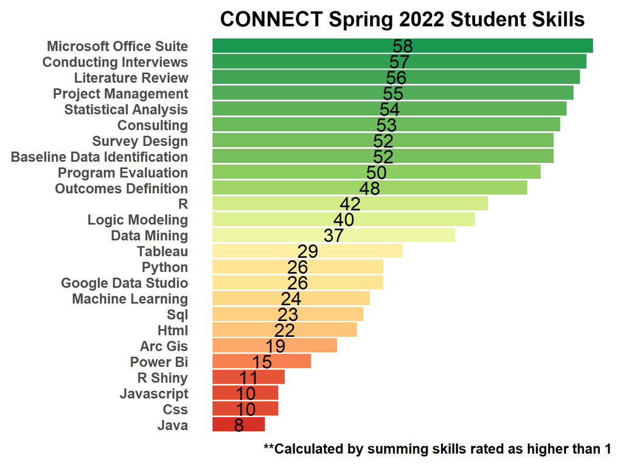

```r
stu2 <- stu |>
  select(first_name, 30:54)

names(stu2) <- gsub(pattern = "_",
                   replacement = " ",
                   x = names(stu2))

names(stu2) <- str_to_title(names(stu2))

stu3 <- stu2 |>
  pivot_longer(col = 2:26,
               names_to = "Skill",
               values_to = "Rating") |>
  #Setting students who put 1 to NA
  mutate(Rating = na_if(Rating, 1)) |>
  drop_na() |>
  group_by(Skill) |>
  count()

theme_set(theme_classic())

g <- ggplot(stu3, aes(x = reorder(Skill, n), y = n, fill = n)) +
  geom_bar(stat = "identity") +
  geom_text(aes(label = n, y = n),
            position = position_stack(vjust = 0.5),
            size = 6) +
  coord_flip() +
  theme(
    panel.grid.major = element_blank(),
    panel.grid.minor = element_blank(),
    axis.line = element_blank(),
    text = element_text(size = 16,
                        face = "bold"),
    axis.title.x = element_blank(),
    axis.title.y = element_blank(),
    axis.ticks = element_blank(),
    axis.text.x = element_blank(),
    plot.title = element_text(hjust = 0.5),
    plot.margin = margin(10, 10, 10, 10),
    legend.title = element_blank(),
    legend.position = "none"

  ) +
  labs(title = "CONNECT Spring 2022 Student Skills",
       caption = "**Calculated by summing skills rated as higher than 1") +
   scale_fill_distiller(palette = "RdYlGn", direction = 1)


g
```

# Matching

In order to use the matching Algorithm, students and organizations have to be assigned a utility ratings. These ratings are formulated by comparing how similar the students’ skills and nonprofit experience are to the project expectations.

Each student receives a utility score for each organization, and each organization is assigned a utility sore for each student. This ensures that both the student’s and organization’s rankings are taken into account for the matching process. For example, if an organization assigns two students the same utility score, but one student has a higher utility score for that organization, this student is selected and the other student returns to the selection pool.

### Utility Score Example

Additionally, if a student put a 1 on a skill, which means they have no background in it, they automatically receive a zero utility rating. Students who don’t match the organization based on the logistics questions, also receive a utility rating of zero.

Finally, all of the skill utility ratings are added up to produce one utility rating for Deepshikha Arora and Athletes For Hope. The higher the number, the greater the utility the student will have for that project.

```r
#Initial Data Manipulation
org1 <- org2[1, ] |>
  pivot_longer(9:34, names_to = "variable", values_to = "org_value")
stu1 <- stu4[1, ] |>
  pivot_longer(6:31, names_to = "variable", values_to = "student_value")

#Assigning a utility score for each skill
match1 <- left_join(org1, stu1, by = "variable") |>
  mutate(
    subtracted = student_value - org_value,
    utility = case_when(
      subtracted >= 0 ~ 1,
      subtracted == -1 ~ .75,
      subtracted == -2 ~ .5,
      subtracted == -3 ~ .25,
      subtracted == -4 ~ 0
    ),
    #if the student put 1 on their survey it means
    #they would provide 0 utility for that skills
    utility = case_when(
      student_value == 1 ~ 0,
      TRUE ~ utility),
    #If the students logistics don't match up with the orgs
    #Then the utility for that student changes to 0
    utility = case_when(
      transportation.x == "Yes" & transportation.y == "No" ~ 0,
      flexible_hours.x == "No" & flexible_hours.y == "Yes" ~ 0,
      remote.x == "No" & remote.y == "Yes" ~ 0,
      TRUE ~ utility
    ),#If the orgs time commitment is greater than what the student
    #is willing to work their utility is set to 0
    utility = case_when(
      time_commitment.x > time_commitment.y ~ 0,
      TRUE ~ utility
    )
  )

utility_score <- sum(match1$utility)
print(paste0(stu1[1,1],"'s utility for ",org1[1,1], ": ", utility_score))
```

```
[1] "Deepshikha Arora's utility for Athletes For Hope: 6"
```

### Organization Utility Scores

For simplicity sake, only the organization utility scores are shown below because their preference matters more in the event of an unsuitable first match. Higher organization utility scores mean that the student is better suited to the organization’s project. These ratings can be validated by reviewing students resumes when necessary.

```r
#utility organizations
row_names <- stu4$name
column_names <- org2$project_name

uO <- matrix(nrow = length(stu4$name),
             ncol = length(org2$project_name),
             dimnames = list(row_names, column_names))


for (j in 1:length(stu4$name)) {
  for (i in 1:length(org2$project_name)) {
    org1 <- org2[i,] |>
      pivot_longer(9:34, names_to = "variable", values_to = "org_value")

    stu1 <- stu4[j,] |>
      pivot_longer(6:31, names_to = "variable", values_to = "student_value")

    match1 <- left_join(org1, stu1, by = "variable") |>
      mutate(
        subtracted =  org_value - student_value,
        utility = case_when(
          subtracted <= 0 ~ 1,
          subtracted == 1 ~ .75,
          subtracted == 2 ~ .5,
          subtracted == 3 ~ .25,
          subtracted >= 4 ~ 0
        ),
        utility = case_when(
          org_value == 1 ~ 0,
          TRUE ~ utility),
        utility = case_when(
          transportation.x == "Yes" & transportation.y == "No" ~ 0,
          flexible_hours.x == "No" & flexible_hours.y == "Yes" ~ 0,
          remote.x == "No" & remote.y == "Yes" ~ 0,
          TRUE ~ utility
        ),
        utility = case_when(time_commitment.x > time_commitment.y ~ 0,
                            TRUE ~ utility)
      )

    utility_score <- sum(match1$utility)
    uO[j, i] <- utility_score
  }
}

#Table Styling
cell_color <- function(x) {
  x = cell_spec(x,
                color = spec_color(x, end = .7),
                bold = T,
                )
}


uO_table <- as.data.frame(uO) |>
  mutate(across(1:15, cell_color))


kbl(uO_table, escape = F) |>
  kable_material(c("hover", "striped", "condensed"), full_width = F) |>
  scroll_box(width = "100%", height = "400px")
```

|  | Athletes For Hope - project 1 | Athletes For Hope - project 2 | Austin Asian Impact | Bastrop County Cares | E4 Youth | Financial Health Pathways | George Washington Carver Museum | Good Apple | Leadership Austin - project 1 | Leadership Austin - project 2 | Leadership Equality Academy | Rebuilding Together Austin | Texas Higher Education Coordinating Board | Texas Higher Education Coordinating Board - project 2 | TransFORWARD |
| --- | --- | --- | --- | --- | --- | --- | --- | --- | --- | --- | --- | --- | --- | --- | --- |
| Deepshikha Arora | 2 | 3.25 | 4 | 0 | 3 | 0.75 | 0 | 4.5 | 4.25 | 0 | 2 | 2.25 | 0 | 0 | 0 |
| Debasmita Bhakta | 4.5 | 5.5 | 6 | 0 | 5.25 | 0 | 0 | 4 | 0 | 0 | 3.75 | 2 | 0 | 0 | 0 |
| Emily Cantwell | 4.5 | 5.5 | 5.5 | 0 | 5.25 | 2.75 | 0 | 4.75 | 6.5 | 0 | 3.5 | 3 | 0 | 0 | 0 |
| Da’Shon Carr | 6.5 | 6.5 | 7 | 4.25 | 6.75 | 4 | 3.75 | 4.5 | 7.25 | 1.75 | 3.75 | 3.25 | 3.25 | 2.75 | 2.5 |
| Francisco Castellanos-Sosa | 5.75 | 6.5 | 6.5 | 4 | 6 | 2.5 | 3.5 | 4.5 | 7.25 | 2 | 4 | 3.25 | 3.75 | 3.25 | 2.25 |
| Vanessa Chebli | 2.75 | 3.75 | 5.5 | 0 | 3.75 | 2.25 | 0 | 3.75 | 5.5 | 0 | 3.25 | 1.5 | 0 | 0 | 0 |
| Grace Chiu | 1.25 | 2.5 | 4 | 0 | 2.5 | 0 | 0 | 5 | 0 | 0 | 1.75 | 4 | 0 | 0 | 0 |
| Taylor Cox | 1.75 | 3 | 3.25 | 0 | 3 | 1 | 0 | 3.75 | 3.5 | 0 | 3 | 1 | 0 | 0 | 0 |
| Melissa Deuber | 2.5 | 3.5 | 3.75 | 3 | 3.75 | 1.75 | 3.25 | 3.5 | 3.75 | 2 | 3.5 | 0.75 | 1.25 | 0.75 | 1.5 |
| Ram Disabar Jr. | 5.25 | 5.5 | 5.75 | 0 | 6.25 | 3.25 | 0 | 4.5 | 6.75 | 0 | 3.75 | 2.5 | 0 | 0 | 0 |
| Angie Fong | 5 | 5 | 6.5 | 3.5 | 6 | 3.75 | 3.25 | 4.5 | 6.5 | 1.25 | 3.25 | 3.5 | 3.25 | 3 | 2 |
| Shelby Frye | 3.75 | 4.5 | 5 | 0 | 4.75 | 2.75 | 0 | 3.25 | 5 | 0 | 3.75 | 0.5 | 0 | 0 | 0 |
| Jaren Gaither | 5 | 5.5 | 7 | 0 | 5.75 | 3.5 | 0 | 4.25 | 7 | 0 | 4 | 2.5 | 0 | 0 | 0 |
| Elena Gonzales Melinger | 5.5 | 5.5 | 6.25 | 3.5 | 6.25 | 4 | 3.75 | 3.5 | 6.75 | 1.75 | 3.75 | 1.5 | 2 | 1.5 | 2 |
| Tara Greig | 4.75 | 5.25 | 6 | 0 | 5.5 | 2.5 | 0 | 5 | 6.5 | 0 | 3.75 | 4 | 0 | 0 | 0 |
| Abigail Grider-Reiff | 5.25 | 5.5 | 6 | 4 | 6 | 3.25 | 4 | 4.5 | 7.25 | 2 | 3.75 | 3.25 | 3.5 | 3 | 2 |
| Brittany Head | 5.5 | 6.25 | 6 | 0 | 6 | 0 | 0 | 4.5 | 0 | 0 | 4 | 3 | 0 | 0 | 0 |
| Emily Hebel | 2.25 | 3.25 | 5 | 0 | 3.5 | 2 | 0 | 4.5 | 5 | 0 | 3.25 | 3 | 0 | 0 | 0 |
| Daisy Hernandez | 4 | 5 | 5.25 | 0 | 5.25 | 2.5 | 0 | 4 | 6.5 | 0 | 3.75 | 2.5 | 0 | 0 | 0 |
| Helen Ho | 2.75 | 3.75 | 4.75 | 0 | 4 | 2.25 | 0 | 4.5 | 4.75 | 0 | 3 | 2.75 | 0 | 0 | 0 |
| Ming-Hung Hung | 5.25 | 6.25 | 6.75 | 4.5 | 5.5 | 2.5 | 3.25 | 5 | 7 | 1.75 | 3.75 | 4.25 | 4.25 | 4.25 | 2.75 |
| Geethu Jacob | 2.5 | 3.75 | 5.5 | 3.75 | 3.75 | 1.75 | 3 | 5 | 5.25 | 2 | 4 | 4 | 4 | 4 | 2.5 |
| Pei-Syuan Jhang | 4.75 | 4.75 | 6 | 0 | 6 | 2.5 | 0 | 3.5 | 6.25 | 0 | 3.5 | 3 | 0 | 0 | 0 |
| Rui Jie Peng | 6 | 6 | 6.75 | 3.75 | 6.5 | 4 | 4 | 4.25 | 7 | 2 | 4 | 3 | 3 | 2.5 | 2.25 |
| Danya Kachkou | 5 | 5.25 | 5.5 | 0 | 6 | 3.75 | 0 | 3.5 | 6.5 | 0 | 4 | 1.5 | 0 | 0 | 0 |
| Isabel Keddy-Hector | 6 | 6 | 6 | 0 | 6.75 | 3.75 | 0 | 4.5 | 7 | 0 | 4 | 2.25 | 0 | 0 | 0 |
| Raeesa Khan | 3.25 | 4.25 | 5.5 | 3.25 | 4 | 2.5 | 2.75 | 3.75 | 5.25 | 1.25 | 3.25 | 1 | 1.5 | 1 | 1.75 |
| Michael Kiel | 4.5 | 5.25 | 6 | 3.75 | 5.5 | 3.25 | 3.5 | 4.25 | 6.75 | 1.75 | 3.75 | 3 | 3.25 | 2.75 | 2.25 |
| Jamie Kim | 3 | 4 | 5 | 3.5 | 4.25 | 1.25 | 2.5 | 4.5 | 5.75 | 1.5 | 3 | 2.5 | 3 | 2.5 | 2 |
| Matthew Kojm | 4.75 | 5.25 | 7.75 | 4.5 | 5.75 | 3.5 | 3.25 | 5 | 7 | 1.5 | 3.5 | 4.25 | 4.5 | 4 | 3 |
| Madison Laboy | 3.5 | 4.25 | 4.5 | 3 | 4.75 | 2.75 | 3.5 | 3.5 | 5.25 | 1.75 | 3.75 | 1.75 | 1.5 | 1 | 1.5 |
| Kim McErlean | 5.75 | 5.75 | 7.25 | 0 | 6.5 | 4 | 0 | 4.25 | 7.5 | 0 | 4 | 2.75 | 0 | 0 | 0 |
| Kliment Minchev | 4.5 | 5 | 6.25 | 3.75 | 5.5 | 2.75 | 3.25 | 5 | 6.75 | 1.75 | 3.5 | 4 | 3.75 | 3.75 | 2.25 |
| Isabel Morford-Cheibub | 3 | 4.25 | 5 | 0 | 4 | 2.25 | 0 | 3.75 | 5.75 | 0 | 3.5 | 1.25 | 0 | 0 | 0 |
| Christopher Ndubuizu | 7 | 7 | 6.75 | 3.5 | 7 | 0 | 0 | 4.5 | 0 | 0 | 4 | 2.75 | 3 | 2.5 | 2 |
| Niina Nomura | 5.5 | 6.25 | 6.25 | 0 | 6 | 3 | 0 | 3.75 | 7 | 0 | 4 | 1.75 | 0 | 0 | 0 |
| Marissa Nunez | 2 | 3 | 3.5 | 2.75 | 3 | 2.5 | 2.25 | 3.25 | 4.25 | 1 | 3 | 0.5 | 1 | 0.5 | 1.5 |
| Abundance Ogodogu Chima | 3.5 | 4.5 | 3.75 | 0 | 4.5 | 0 | 0 | 3.75 | 0 | 0 | 3 | 1 | 0 | 0 | 0 |
| Madie Olson Spartz | 3.75 | 4.75 | 4.75 | 0 | 4.5 | 2.75 | 0 | 3.5 | 6 | 0 | 3.25 | 1 | 0 | 0 | 0 |
| Sabrina Page | 2.25 | 3.5 | 4 | 0 | 3.25 | 2.5 | 0 | 3.5 | 3.75 | 0 | 3 | 0.75 | 0 | 0 | 0 |
| Afnaan Qayyum | 4.25 | 4.75 | 5.5 | 0 | 5.25 | 0 | 0 | 4 | 0 | 0 | 3.75 | 1.5 | 0 | 0 | 0 |
| Sravan Reddy Chilumula | 5.25 | 6 | 6 | 4.25 | 6 | 2.75 | 3.75 | 5 | 6.75 | 2 | 4 | 4.5 | 4 | 4 | 2.5 |
| Het Ripple Patel | 5.25 | 6 | 7.25 | 4.25 | 5.75 | 0 | 0 | 5 | 0 | 0 | 3.75 | 4.5 | 4.25 | 4 | 2.75 |
| Srujan Rode | 3.25 | 4.25 | 5 | 3.75 | 4.5 | 2.5 | 2.5 | 4.25 | 5 | 1 | 3 | 2 | 2.5 | 2 | 2.25 |
| Patricia Romero | 0 | 0 | 0 | 0 | 0 | 0 | 0 | 0 | 0 | 0 | 0 | 0 | 0 | 0 | 0 |
| Lauren Rosa | 0 | 0 | 0 | 0 | 0 | 0 | 0 | 0 | 0 | 0 | 0 | 0 | 0 | 0 | 0 |
| Ishita Roy | 1.25 | 2.5 | 5 | 4 | 2.5 | 1 | 2 | 4.75 | 4.25 | 1.25 | 3 | 4.25 | 3.75 | 3.75 | 2.75 |
| Mikhaela Sample | 2.5 | 3.75 | 4.5 | 0 | 3.25 | 2.25 | 0 | 4 | 4.75 | 0 | 2.5 | 1.75 | 0 | 0 | 0 |
| Holly Sarkissian | 6.25 | 6.75 | 6.75 | 4 | 6.5 | 3.5 | 3.75 | 4.5 | 7.5 | 2 | 4 | 2.75 | 3 | 2.5 | 2.5 |
| Neil Schwartz | 4.75 | 5.5 | 5 | 0 | 6 | 2.5 | 0 | 4 | 6.5 | 0 | 3.75 | 2 | 0 | 0 | 0 |
| Rania Sohail | 5.5 | 5.75 | 5.75 | 0 | 6 | 0 | 0 | 4.5 | 0 | 0 | 3.75 | 2.25 | 0 | 0 | 0 |
| Nathan Stern | 3 | 4 | 5.5 | 4.25 | 4.25 | 1.75 | 2.5 | 4.25 | 5 | 1.25 | 2.5 | 3 | 3.5 | 3 | 2.5 |
| Parth Sujit Shinde | 5.5 | 6.25 | 7.25 | 4.5 | 5.75 | 0 | 0 | 5 | 0 | 0 | 3.75 | 4.75 | 4.5 | 4.25 | 2.75 |
| Nishat Tasnim | 6.75 | 6.75 | 7.25 | 0 | 7 | 0 | 0 | 4.25 | 0 | 0 | 4 | 2.5 | 0 | 0 | 0 |
| Cooper Thompson | 6.25 | 6.25 | 5.5 | 3.5 | 6.5 | 3.5 | 4 | 4 | 6.75 | 2 | 3.75 | 1.75 | 1.75 | 1.25 | 2 |
| Jin Yan | 6.75 | 6.75 | 7.25 | 4.5 | 7 | 4 | 4 | 5 | 7.75 | 2 | 4 | 4.25 | 4.5 | 4.25 | 2.5 |
| Hyesun You | 5.75 | 6.25 | 7.25 | 4.5 | 6.25 | 3.25 | 3.5 | 4.5 | 7.75 | 2 | 4 | 4.25 | 4 | 3.5 | 2.5 |
| Mayra Yundt-Pacheco | 5.5 | 6 | 5.75 | 3.75 | 6 | 2.75 | 3.5 | 4.75 | 7.5 | 2 | 3.75 | 2.75 | 3.25 | 2.75 | 2 |
| Shiyang Zhang | 5.5 | 6 | 6.75 | 0 | 5.75 | 3.25 | 0 | 5 | 7 | 0 | 3.5 | 4 | 0 | 0 | 0 |

### The Gale Shapley Algorithm

```r
#Matching Algorithm
matching = galeShapley.marriageMarket(uS, uO)
```

### Matching Results

The table below shows the matching results. Matches should be validated by reviewing student resumes to ensure they have relevant work experience. The table also shows a list of all the top scorers for each project. Program managers can use this list to help them find a match if the first wasn’t suitable.

```r
#Creating a list of top scorers
uO2 <- as.data.frame(uO)
org_options <- tibble::rownames_to_column(uO2, "Student")
tops <- list()

for (i in 2:ncol(org_options)) {
  org_top <- org_options |>
    slice_max(org_options[,i], n = 3)

tops[[i]] <- paste(org_top$Student, collapse=", ")
}

tops <- tops[-1]
top_df <- data.frame(matrix(unlist(tops), nrow=length(tops), byrow=TRUE))

top_df$matrix.unlist.tops...nrow...length.tops...byrow...TRUE.<-
  gsub("\\."," ",top_df$matrix.unlist.tops...nrow...length.tops...byrow...TRUE.)

#Creating a data frame for table
org_info <- org2 |>
  select(project_name)

students_matched <- stu4 |>
  slice(matching$engagements) |>
  bind_cols(org_info) |>
  bind_cols(top_df) |>
  rename(Student = name,
         Project = project_name,
         "Top Scores" = "matrix.unlist.tops...nrow...length.tops...byrow...TRUE.") |>
  select(Project, Student,"Top Scores")


var_label(students_matched$Project) <- NULL



kbl(students_matched) |>
  kable_material(c("hover","striped"), full_width = F) |>
  scroll_box(width = "100%", height = "600px")
```

| Project | Student | Top Scores |
| --- | --- | --- |
| Athletes For Hope - project 1 | Christopher Ndubuizu | Christopher Ndubuizu, Nishat Tasnim, Jin Yan |
| Athletes For Hope - project 2 | Holly Sarkissian | Christopher Ndubuizu, Holly Sarkissian, Nishat Tasnim, Jin Yan |
| Austin Asian Impact | Het Ripple Patel | Matthew Kojm, Kim McErlean, Het Ripple Patel, Parth Sujit Shinde, Nishat Tasnim, Jin Yan, Hyesun You |
| Bastrop County Cares | Ming-Hung Hung | Ming-Hung Hung, Matthew Kojm, Parth Sujit Shinde, Jin Yan, Hyesun You |
| E4 Youth | Jin Yan | Christopher Ndubuizu, Nishat Tasnim, Jin Yan |
| Financial Health Pathways | Kim McErlean | Da’Shon Carr, Elena Gonzales Melinger, Rui Jie Peng, Kim McErlean, Jin Yan |
| George Washington Carver Museum | Cooper Thompson | Abigail Grider-Reiff, Rui Jie Peng, Cooper Thompson, Jin Yan |
| Good Apple | Shiyang Zhang | Grace Chiu, Tara Greig, Ming-Hung Hung, Geethu Jacob, Matthew Kojm, Kliment Minchev, Sravan Reddy Chilumula, Het Ripple Patel, Parth Sujit Shinde, Jin Yan, Shiyang Zhang |
| Leadership Austin - project 1 | Francisco Castellanos-Sosa | Jin Yan, Hyesun You, Kim McErlean, Holly Sarkissian, Mayra Yundt-Pacheco |
| Leadership Austin - project 2 | Mayra Yundt-Pacheco | Francisco Castellanos-Sosa, Melissa Deuber, Abigail Grider-Reiff, Geethu Jacob, Rui Jie Peng, Sravan Reddy Chilumula, Holly Sarkissian, Cooper Thompson, Jin Yan, Hyesun You, Mayra Yundt-Pacheco |
| Leadership Equality Academy | Hyesun You | Francisco Castellanos-Sosa, Jaren Gaither, Brittany Head, Geethu Jacob, Rui Jie Peng, Danya Kachkou, Isabel Keddy-Hector, Kim McErlean, Christopher Ndubuizu, Niina Nomura, Sravan Reddy Chilumula, Holl… |
| Rebuilding Together Austin | Ishita Roy | Parth Sujit Shinde, Sravan Reddy Chilumula, Het Ripple Patel |
| Texas Higher Education Coordinating Board | Parth Sujit Shinde | Matthew Kojm, Parth Sujit Shinde, Jin Yan |
| Texas Higher Education Coordinating Board - project 2 | Sravan Reddy Chilumula | Ming-Hung Hung, Parth Sujit Shinde, Jin Yan |
| TransFORWARD | Matthew Kojm | Matthew Kojm, Ming-Hung Hung, Het Ripple Patel, Ishita Roy, Parth Sujit Shinde |

[figure not shown]